# 빅데이터를 활용한 경제분석 보고서

```
                                           --전력 생산량과 소비량이 GDP에 대한 영향
                                             경제금융학과 2019177366 장동
```

## 목차

### 1.연구 문제

### 2.모델 설명

### 3.Data 설명

### 4.Code와 요약 통계 & 결과

### 5.Visualization

### 6.향후 진행 계획

### 1.연구 문제

- 온실가스 배출을 줄이고 갈수록 심각해지는 기후변화 문제를 개선하기 위해서는 석탄을 주요 발전원료로 사용하는 전력산업에 대한 연구가 필요하다.
- 중국은 2015년 전력개혁을 진행했다.그 개혁 목표 중 하나는 재생에너지의 발전량을 늘려 온실가스 배출을 줄이는 것이다.이 때문에 풍력·태양광을 비롯한 재생에너지가 최근 몇 년간 발전 시스템에 많이 사용되고 있다.
- 그럼 풍력·태양광 발전 생산량과 GDP의 어떤 관계가 존재한가?
- 전력 소비량과 석탄 소비량이 GDP에 어떤 영향을 미칠 것인가?

위 두 문제에 대해 연구를 시작한다.

### 2.모델 설명

- 모델이 두개를 만들었다.
  - 1) 중국 전국 발전 생산량과 GDP에 관한 모델이다.
  - 2) 중국 전국 전력 소비량,석탁 소비량과 GDP의 관계를 살펴보는 모델이다.

#### 1)중국 전국 발전 생산량과 GDP에 관한 모델이다.

$${y_i}=\alpha+\beta_{1}{x1_i}+\beta_{2}{x2_i}+\beta_{3}{x3_i}+\beta_{4}{x4_i}+\epsilon_i$$

$$y_i -GDP$$ $$x1_i -Electricity produced by hydropower$$ $$x2_i -Electricity produced by thermal power$$ $$x3_i -Electricity produced by nuclear power$$ $$x4_i -Electricity produced by wind power$$

#### 2)중국 전국 발전 소비량,석탄 소비량과 GDP에 관한 모델이다.

$${y_i}=\alpha+\beta{x_i}+\lambda{z_i}+\epsilon_i$$

$$y_i -GDP$$ $$x_i -Electricity consumption$$ $$z_i -Coal consumption$$

### 3.Data 설명

Data From:중국 국가 통계국 사이트 (https://data.stats.gov.cn/index.htm)

**Model 1-Data 설명**

| Data 이름 | Data 시간열 |
| --- | --- |
| GDP | 2008-2018 |
| Electricity produced by hydropower | 2008-2018 |
| Electricity produced by thermal power | 2008-2018 |
| Electricity produced by nuclear power | 2008-2018 |
| Electricity produced by wind power | 2008-2018 |

**Model 2-Data 설명**

| Data 이름 | Data 시간열 |
| --- | --- |
| GDP | 2008-2018 |
| Electricity consumption | 2008-2018 |
| Coal consumption | 2008-2018 |

### 4.Code와 요약 통계 & 결과

```python
import requests
import numpy as np
import pandas as pd
from bs4 import BeautifulSoup
import time
import json

def getTime():
    return int(round(time.time()*1000))
```

#### Data-WebCrawler-GDP

```python
#GDP DATA
url='https://data.stats.gov.cn/easyquery.htm?m=QueryData&dbcode=hgnd&rowcode=zb&colcode=sj&wds=%5B%5D&dfwds=%5B%7B%22wdcode%22%3A%22sj%22%2C%22valuecode%22%3A%222008-2018%22%7D%5D&k1=1640166047285'
headers={'User-Agent':'Mozilla/5.0 (Windows NT 10.0; Win64; x64) AppleWebKit/537.36 (KHTML, like Gecko) Chrome/95.0.4638.54 Safari/537.36'}
key={}
key['m']='QueryData'
key['dbcode']='hgnd'
key['rowcode']='zb'
key['colcode']='sj'
key['wds']='[]'
key['dfwds']='[{"wdcode":"sj","valuecode":"2008-2018"}]'
key['k1']=str(getTime())
r=requests.get(url,headers=headers,verify=False)
js=json.loads(r.text)
length=len(js['returndata']['datanodes'])
def getList(l):
    List=[]
    for i in range(length):
        List.append(js['returndata']['datanodes'][i]['data']['strdata'])
    return List
lst=getList(length)
array=np.array(lst).reshape(6,11)
df_1=pd.DataFrame(array)
df_1.index=['Gross national income',
'GDP',
'Added value of primary industry',
'Added value of the secondary industry',
'Added value of tertiary industry',
'GDP per capita']
df_1.columns=['2018','2017','2016','2015','2014','2013','2012','2011','2010','2009','2008']
df_1
```

|  | 2018 | 2017 | 2016 | 2015 | 2014 | 2013 | 2012 | 2011 | 2010 | 2009 | 2008 |
| --- | --- | --- | --- | --- | --- | --- | --- | --- | --- | --- | --- |
| Gross national income | 915243.5 | 830945.7 | 742694.1 | 685571.2 | 644380.2 | 588141.2 | 537329.0 | 483392.8 | 410354.1 | 347934.9 | 321229.5 |
| GDP | 919281.1 | 832035.9 | 746395.1 | 688858.2 | 643563.1 | 592963.2 | 538580.0 | 487940.2 | 412119.3 | 348517.7 | 319244.6 |
| Added value of primary industry | 64745.2 | 62099.5 | 60139.2 | 57774.6 | 55626.3 | 53028.1 | 49084.6 | 44781.5 | 38430.8 | 33583.8 | 32464.1 |
| Added value of the secondary industry | 364835.2 | 331580.5 | 295427.8 | 281338.9 | 277282.8 | 261951.6 | 244639.1 | 227035.1 | 191626.5 | 160168.8 | 149952.9 |
| Added value of tertiary industry | 489700.8 | 438355.9 | 390828.1 | 349744.7 | 310654.0 | 277983.5 | 244856.2 | 216123.6 | 182061.9 | 154765.1 | 136827.5 |
| GDP per capita | 65534 | 59592 | 53783 | 49922 | 46912 | 43497 | 39771 | 36277 | 30808 | 26180 | 24100 |

```python
data_frame_save = df_1.copy()
data_frame_save = data_frame_save.transpose()
data_frame_save["GDP"] = df_1.loc["GDP", :]
data_frame_save.to_csv("./data.csv", encoding="utf-8-sig")

df_1.to_csv(r"E:\shuju\gdp.csv", encoding="utf-8-sig")
```

#### Data-WebCrawler-production

```python
#PRODUCTION DATA
url='https://data.stats.gov.cn/easyquery.htm?m=QueryData&dbcode=hgnd&rowcode=zb&colcode=sj&wds=%5B%5D&dfwds=%5B%7B%22wdcode%22%3A%22sj%22%2C%22valuecode%22%3A%222008-2018%22%7D%5D&k1=1640166562453'
headers={'User-Agent':'Mozilla/5.0 (Windows NT 10.0; Win64; x64) AppleWebKit/537.36 (KHTML, like Gecko) Chrome/95.0.4638.54 Safari/537.36'}
key={}
key['m']='QueryData'
key['dbcode']='hgnd'
key['rowcode']='zb'
key['colcode']='sj'
key['wds']='[]'
key['dfwds']='[{"wdcode":"sj","valuecode":"2008-2018"}]'
key['k1']=str(getTime())
r=requests.get(url,headers=headers,verify=False)
js=json.loads(r.text)
length=len(js['returndata']['datanodes'])
def getList(l):
    List=[]
    for i in range(length):
        List.append(js['returndata']['datanodes'][i]['data']['strdata'])
    return List
lst=getList(length)
array=np.array(lst).reshape(19,11)
df_2=pd.DataFrame(array)
df_2.index=['Power supply',
'Electricity production',
'Electricity produced by hydropower',
'Electricity produced by thermal power',
'Electricity produced by nuclear power',
'Electricity produced by wind power',
'Electricity imports',
'Electricity exports',
'Total electricity energy consumption',
'Total power consumption of agriculture, forestry, animal husbandry and fishery',
'Total industrial power consumption',
'Total electricity consumption in construction industry',
'Total electricity consumption in transportation, storage and postal industry',
'Total electricity consumption in wholesale and retail, accommodation and catering industries',
'Total other electricity consumption',
'Residents total electricity consumption',
'Electricity terminal consumption',
'Power consumption of industrial terminals',
'Transmission and distribution losses']
df_2.columns=['2018','2017','2016','2015','2014','2013','2012','2011','2010','2009','2008']
df_2
```

|  | 2018 | 2017 | 2016 | 2015 | 2014 | 2013 | 2012 | 2011 | 2010 | 2009 | 2008 |
| --- | --- | --- | --- | --- | --- | --- | --- | --- | --- | --- | --- |
| Power supply | 71509.2 | 65914.0 | 61204.4 | 58021.3 | 57830.5 | 54204.1 | 49767.7 | 47002.7 | 41936.5 | 37032.7 | 34540.8 |
| Electricity production | 71661.3 | 66044.5 | 61331.6 | 58145.7 | 57944.6 | 54316.4 | 49875.5 | 47130.2 | 42071.6 | 37146.5 | 34668.8 |
| Electricity produced by hydropower | 12317.9 | 11978.7 | 11840.5 | 11302.7 | 10728.8 | 9202.9 | 8721.1 | 6989.5 | 7221.7 | 6156.4 | 5851.9 |
| Electricity produced by thermal power | 50963.2 | 47546.0 | 44370.7 | 42841.9 | 44001.1 | 42470.1 | 38928.1 | 38337.0 | 33319.3 | 29827.8 | 27900.8 |
| Electricity produced by nuclear power | 2943.6 | 2480.7 | 2132.9 | 1707.9 | 1325.4 | 1116.1 | 973.9 | 863.5 | 738.8 | 701.3 | 683.9 |
| Electricity produced by wind power | 3659.7 | 2972.3 | 2370.7 | 1857.7 | 1599.8 | 1412.0 | 959.8 | 703.3 | 446.2 |  |  |
| Electricity imports | 56.9 | 64.2 | 61.9 | 62.1 | 67.5 | 74.4 | 68.7 | 65.6 | 55.5 | 60.1 | 38.4 |
| Electricity exports | 209.1 | 194.7 | 189.1 | 186.5 | 181.6 | 186.7 | 176.5 | 193.1 | 190.6 | 173.9 | 166.4 |
| Total electricity energy consumption | 71508.2 | 65914.0 | 61205.1 | 58020.0 | 57829.7 | 54203.4 | 49762.6 | 47000.9 | 41934.5 | 37032.2 | 34541.4 |
| Total power consumption of agriculture, forestry, animal husbandry and fishery | 1242.5 | 1175.1 | 1091.9 | 1039.8 | 1013.4 | 1026.9 | 1012.6 | 1012.9 | 976.5 | 939.9 | 887.1 |
| Total industrial power consumption | 49094.9 | 46052.8 | 42996.9 | 41550.0 | 42248.7 | 39236.9 | 36232.2 | 34691.6 | 30871.8 | 26854.5 | 25388.6 |
| Total electricity consumption in construction industry | 887.8 | 789.2 | 725.6 | 698.7 | 721.7 | 675.1 | 608.4 | 571.8 | 483.2 | 421.9 | 367.3 |
| Total electricity consumption in transportation, storage and postal industry | 1608.5 | 1418.0 | 1251.5 | 1125.6 | 1059.2 | 1000.9 | 915.4 | 848.4 | 734.5 | 617.0 | 571.8 |
| Total electricity consumption in wholesale and retail, accommodation and catering industries | 2900.4 | 2526.6 | 2323.8 | 2122.0 | 1995.6 | 1876.9 | 1691.5 | 1503.1 | 1292.0 | 1136.8 | 1017.4 |
| Total other electricity consumption | 5716.5 | 4880.6 | 4394.8 | 3918.6 | 3615.0 | 3397.6 | 3083.6 | 2753.1 | 2451.8 | 2189.9 | 1913.0 |
| Residents total electricity consumption | 10057.6 | 9071.6 | 8420.6 | 7565.2 | 7176.1 | 6989.2 | 6219.0 | 5620.1 | 5124.6 | 4872.2 | 4396.1 |
| Electricity terminal consumption | 68156.5 | 62718.1 | 58142.2 | 55032.1 | 54729.8 | 51062.7 | 46866.5 | 44300.2 | 39366.3 | 34773.9 | 32403.5 |
| Power consumption of industrial terminals | 45743.2 | 42857.0 | 39934.0 | 38562.1 | 39148.8 | 36096.2 | 33336.1 | 31990.9 | 28303.5 | 24596.3 | 23250.8 |
| Transmission and distribution losses | 3351.7 | 3195.8 | 3062.9 | 2987.9 | 3099.9 | 3140.7 | 2896.2 | 2700.7 | 2568.2 | 2258.2 | 2137.9 |

```python
data_frame_save = df_2.copy()
data_frame_save = data_frame_save.transpose()
data_frame_save["Power supply"] = df_2.loc["Power supply", :]
data_frame_save.to_csv("./data.csv", encoding="utf-8-sig")
```

#### Data-WebCrawler-consumption

```python
#CONSUMPTION DATA
url='https://data.stats.gov.cn/easyquery.htm?m=QueryData&dbcode=hgnd&rowcode=zb&colcode=sj&wds=%5B%5D&dfwds=%5B%7B%22wdcode%22%3A%22sj%22%2C%22valuecode%22%3A%222008-2018%22%7D%5D&k1=1640166741800'
headers={'User-Agent':'Mozilla/5.0 (Windows NT 10.0; Win64; x64) AppleWebKit/537.36 (KHTML, like Gecko) Chrome/95.0.4638.54 Safari/537.36'}
key={}
key['m']='QueryData'
key['dbcode']='hgnd'
key['rowcode']='zb'
key['colcode']='sj'
key['wds']='[]'
key['dfwds']='[{"wdcode":"sj","valuecode":"2008-2018"}]'
key['k1']=str(getTime())
r=requests.get(url,headers=headers,verify=False)
js=json.loads(r.text)
length=len(js['returndata']['datanodes'])
def getList(l):
    List=[]
    for i in range(length):
        List.append(js['returndata']['datanodes'][i]['data']['strdata'])
    return List
lst=getList(length)
array=np.array(lst).reshape(14,11)
df_3=pd.DataFrame(array)
df_3.index=['Total energy consumption',
'Coal share of total energy consumption',
'The share of oil in total energy consumption',
'The proportion of natural gas in total energy consumption',
'The proportion of primary power and other energy in total energy',
'Coal consumption',
'Coke consumption',
'Crude oil consumption',
'Gasoline consumption',
'Kerosene consumption',
'Diesel consumption',
'Fuel oil consumption',
'Natural gas consumption',
'Electricity consumption']
df_3.columns=['2018','2017','2016','2015','2014','2013','2012','2011','2010','2009','2008']
df_3
```

|  | 2018 | 2017 | 2016 | 2015 | 2014 | 2013 | 2012 | 2011 | 2010 | 2009 | 2008 |
| --- | --- | --- | --- | --- | --- | --- | --- | --- | --- | --- | --- |
| Total energy consumption | 471925 | 455827 | 441492 | 434113 | 428334 | 416913 | 402138 | 387043 | 360648 | 336126 | 320611 |
| Coal share of total energy consumption | 59.0 | 60.6 | 62.2 | 63.8 | 65.8 | 67.4 | 68.5 | 70.2 | 69.2 | 71.6 | 71.5 |
| The share of oil in total energy consumption | 18.9 | 18.9 | 18.7 | 18.4 | 17.3 | 17.1 | 17.0 | 16.8 | 17.4 | 16.4 | 16.7 |
| The proportion of natural gas in total energy consumption | 7.6 | 6.9 | 6.1 | 5.8 | 5.6 | 5.3 | 4.8 | 4.6 | 4.0 | 3.5 | 3.4 |
| The proportion of primary power and other energy in total energy | 14.5 | 13.6 | 13.0 | 12.0 | 11.3 | 10.2 | 9.7 | 8.4 | 9.4 | 8.5 | 8.4 |
| Coal consumption | 397452.00 | 391403.00 | 388820.00 | 399834.00 | 413633.00 | 424426.00 | 411727.00 | 388961.00 | 349008.00 | 325003.00 | 281095.92 |
| Coke consumption | 43717.00 | 43743.00 | 45462.00 | 44059.00 | 46885.00 | 45852.00 | 44805.00 | 42063.00 | 38703.00 | 36350.00 | 29900.23 |
| Crude oil consumption | 63004.33 | 59402.17 | 57125.93 | 54788.28 | 51596.95 | 48652.15 | 46678.92 | 43965.84 | 42874.55 | 38128.59 | 35498.24 |
| Gasoline consumption | 13055.30 | 12296.27 | 11866.04 | 11368.46 | 9776.37 | 9366.35 | 8165.90 | 7595.95 | 6956.20 | 6172.69 | 6145.52 |
| Kerosene consumption | 3653.51 | 3326.36 | 2970.71 | 2663.71 | 2335.42 | 2164.07 | 1956.60 | 1816.72 | 1765.17 | 1450.49 | 1294.01 |
| Diesel consumption | 16409.56 | 16916.54 | 16839.04 | 17360.31 | 17165.29 | 17150.65 | 16966.04 | 15635.10 | 14699.00 | 13551.43 | 13532.58 |
| Fuel oil consumption | 4536.07 | 4887.30 | 4631.04 | 4662.01 | 4355.47 | 3953.97 | 3683.28 | 3662.80 | 3758.02 | 2828.80 | 3237.15 |
| Natural gas consumption | 2817.09 | 2393.69 | 2078.06 | 1931.75 | 1870.63 | 1705.37 | 1497.00 | 1341.07 | 1080.24 | 895.20 | 812.94 |
| Electricity consumption | 71508.20 | 65913.97 | 61205.09 | 58019.98 | 57829.69 | 54203.41 | 49762.64 | 47000.88 | 41934.49 | 37032.14 | 34541.35 |

```python
data_frame_save = df_3.copy()
data_frame_save = data_frame_save.transpose()
data_frame_save["Total energy consumption"] = df_3.loc["Total energy consumption", :]
data_frame_save.to_csv("./data.csv", encoding="utf-8-sig")

df_3.to_csv(r"E:\shuju\production.csv", encoding="utf-8-sig")
```

```python
import pandas as pd
import numpy as np
import matplotlib.pyplot as plt
import statsmodels.api as sm
```

```python
data=pd.read_excel('E:/shuju/my data.xlsx',index_col=0)
data=pd.DataFrame(data)
data_1=data.transpose()
data_1.head(20)
```

|  | GDP | Electricity production | Electricity produced by hydropower | Electricity produced by thermal power | Electricity produced by nuclear power | Electricity produced by wind power | Electricity consumption | Coal consumption |
| --- | --- | --- | --- | --- | --- | --- | --- | --- |
| 2018 | 919281.1 | 71661.3 | 12317.9 | 50963.2 | 2943.6 | 3659.7 | 71508.20 | 397452.00 |
| 2017 | 832035.9 | 66044.5 | 11978.7 | 47546.0 | 2480.7 | 2972.3 | 65913.97 | 391403.00 |
| 2016 | 746395.1 | 61331.6 | 11840.5 | 44370.7 | 2132.9 | 2370.7 | 61205.09 | 388820.00 |
| 2015 | 688858.2 | 58145.7 | 11302.7 | 42841.9 | 1707.9 | 1857.7 | 58019.98 | 399834.00 |
| 2014 | 643563.1 | 57944.6 | 10728.8 | 44001.1 | 1325.4 | 1599.8 | 57829.69 | 413633.00 |
| 2013 | 592963.2 | 54316.4 | 9202.9 | 42470.1 | 1116.1 | 1412.0 | 54203.41 | 424426.00 |
| 2012 | 538580.0 | 49875.5 | 8721.1 | 38928.1 | 973.9 | 959.8 | 49762.64 | 411727.00 |
| 2011 | 487940.2 | 47130.2 | 6989.4 | 38337.0 | 863.5 | 703.3 | 47000.88 | 388961.00 |
| 2010 | 412119.3 | 42071.6 | 7221.7 | 33319.3 | 738.8 | 446.2 | 41934.49 | 349008.00 |
| 2009 | 348517.7 | 37146.5 | 6156.4 | 29827.8 | 701.3 | 276.2 | 37032.14 | 325003.00 |
| 2008 | 319244.6 | 34668.8 | 5851.9 | 27900.8 | 683.9 | 130.8 | 34541.35 | 281095.92 |

```python
data_1.describe()
```

|  | GDP | Electricity production | Electricity produced by hydropower | Electricity produced by thermal power | Electricity produced by nuclear power | Electricity produced by wind power | Electricity consumption | Coal consumption |
| --- | --- | --- | --- | --- | --- | --- | --- | --- |
| count | 11.000000 | 11.000000 | 11.000000 | 11.00000 | 11.000000 | 11.000000 | 11.000000 | 11.000000 |
| mean | 593590.763636 | 52757.881818 | 9301.090909 | 40046.00000 | 1424.363636 | 1489.863636 | 52631.985455 | 379214.810909 |
| std | 195012.742657 | 11793.419200 | 2460.973983 | 7244.38257 | 785.477752 | 1146.475008 | 11788.731373 | 43425.729996 |
| min | 319244.600000 | 34668.800000 | 5851.900000 | 27900.80000 | 683.900000 | 130.800000 | 34541.350000 | 281095.920000 |
| 25% | 450029.750000 | 44600.900000 | 7105.550000 | 35828.15000 | 801.150000 | 574.750000 | 44467.685000 | 368914.000000 |
| 50% | 592963.200000 | 54316.400000 | 9202.900000 | 42470.10000 | 1116.100000 | 1412.000000 | 54203.410000 | 391403.000000 |
| 75% | 717626.650000 | 59738.650000 | 11571.600000 | 44185.90000 | 1920.400000 | 2114.200000 | 59612.535000 | 405780.500000 |
| max | 919281.100000 | 71661.300000 | 12317.900000 | 50963.20000 | 2943.600000 | 3659.700000 | 71508.200000 | 424426.000000 |

```python
#ols-GDP&PRODUCTION
y=data_1['GDP']
x=data_1[['Electricity produced by hydropower',
          'Electricity produced by thermal power',
          'Electricity produced by nuclear power',
          'Electricity produced by wind power']]
x=sm.add_constant(x)
est=sm.OLS(y,x)
model=est.fit()
print(model.summary())
```

```
                            OLS Regression Results
==============================================================================
Dep. Variable:                    GDP   R-squared:                       0.999
Model:                            OLS   Adj. R-squared:                  0.999
Method:                 Least Squares   F-statistic:                     1975.
Date:                Wed, 22 Dec 2021   Prob (F-statistic):           1.75e-09
Time:                        18:53:59   Log-Likelihood:                -109.56
No. Observations:                  11   AIC:                             229.1
Df Residuals:                       6   BIC:                             231.1
Df Model:                           4
Covariance Type:            nonrobust
=========================================================================================================
                                            coef    std err          t      P>|t|      [0.025      0.975]
---------------------------------------------------------------------------------------------------------
const                                 -2.126e+05   6.94e+04     -3.063      0.022   -3.82e+05   -4.27e+04
Electricity produced by hydropower       12.4026      3.043      4.076      0.007       4.957      19.848
Electricity produced by thermal power    13.7901      1.963      7.024      0.000       8.986      18.594
Electricity produced by nuclear power   112.7718     35.786      3.151      0.020      25.205     200.338
Electricity produced by wind power      -14.8226     33.519     -0.442      0.674     -96.841      67.196
==============================================================================
Omnibus:                        0.889   Durbin-Watson:                   2.843
Prob(Omnibus):                  0.641   Jarque-Bera (JB):                0.148
Skew:                           0.284   Prob(JB):                        0.928
Kurtosis:                       2.969   Cond. No.                     1.39e+06
==============================================================================

Notes:
[1] Standard Errors assume that the covariance matrix of the errors is correctly specified.
[2] The condition number is large, 1.39e+06. This might indicate that there are
strong multicollinearity or other numerical problems.
```

#### Model-1 중국 전국 발전 생산량과 GDP에 관한 모델이다.

  *이 결과도 중국의 현재 상황이 좀 비슷합니다.2021년 9월에는 중국 동북쪽 지역에서전력 부족으로 인해 많은 문제가 나타났습니다.* *그 중에 제일 큰 원인은 풍력 발전량 궁급 부족 문제이기 때문이다.*

```python
#GDP&CONSUMPTION
y=data_1['GDP']
x=data_1[['Electricity consumption','Coal consumption']]
x=sm.add_constant(x)
est=sm.OLS(y,x)
model_1=est.fit()
print(model_1.summary())
```

```
                            OLS Regression Results
==============================================================================
Dep. Variable:                    GDP   R-squared:                       0.997
Model:                            OLS   Adj. R-squared:                  0.997
Method:                 Least Squares   F-statistic:                     1425.
Date:                Wed, 22 Dec 2021   Prob (F-statistic):           6.14e-11
Time:                        18:54:00   Log-Likelihood:                -116.74
No. Observations:                  11   AIC:                             239.5
Df Residuals:                       8   BIC:                             240.7
Df Model:                           2
Covariance Type:            nonrobust
===========================================================================================
                              coef    std err          t      P>|t|      [0.025      0.975]
-------------------------------------------------------------------------------------------
const                   -1.424e+05   3.37e+04     -4.232      0.003    -2.2e+05   -6.48e+04
Electricity consumption    17.9416      0.454     39.527      0.000      16.895      18.988
Coal consumption           -0.5493      0.123     -4.457      0.002      -0.833      -0.265
==============================================================================
Omnibus:                        5.900   Durbin-Watson:                   2.343
Prob(Omnibus):                  0.052   Jarque-Bera (JB):                2.253
Skew:                          -0.994   Prob(JB):                        0.324
Kurtosis:                       3.980   Cond. No.                     3.73e+06
==============================================================================

Notes:
[1] Standard Errors assume that the covariance matrix of the errors is correctly specified.
[2] The condition number is large, 3.73e+06. This might indicate that there are
strong multicollinearity or other numerical problems.
```

#### Model-2 중국 전국 발전 소비량,석탁 소비량과 GDP에 관한 모델이다.

- 결과를 보면,
  - 전력 소비량이 GDP에 대해 다 postive 영향을 줄 수 있다.
  - 그런데 **석탄 소비량**이 GDP에 대해 **negative** 영향을 미칠 것이다.

*이것도 석탄소비가 많으면 더 많은 환경문제가 일으킬 수 있기 때문에 GDP에 대해도 좋을 영향을 미칠 수 없습니다.*

### 5.Visualization

```python
import numpy as np
import matplotlib.mlab as mlab
import matplotlib.pyplot as plt

%matplotlib inline

plt.style.use("ggplot")
```

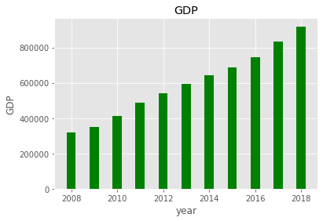

```python
x = [2018,2017,2016,2015,2014,2013,2012,2011,2010,2009,2008]
y = data_1['GDP']
fig = plt.figure()
plt.bar(x,y,0.4,color="green")
plt.xlabel("year")
plt.ylabel("GDP")
plt.title("GDP")

plt.show()
```

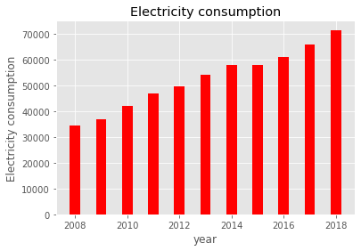

```python
x = [2018,2017,2016,2015,2014,2013,2012,2011,2010,2009,2008]
y = data_1['Electricity consumption']
fig = plt.figure()
plt.bar(x,y,0.4,color="red")
plt.xlabel("year")
plt.ylabel("Electricity consumption")
plt.title("Electricity consumption")

plt.show()
```

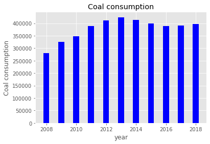

```python
x = [2018,2017,2016,2015,2014,2013,2012,2011,2010,2009,2008]
y = data_1['Coal consumption']
fig = plt.figure()
plt.bar(x,y,0.4,color="blue")
plt.xlabel("year")
plt.ylabel("Coal consumption")
plt.title("Coal consumption")

plt.show()
```

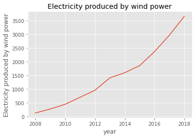

```python
x = [2018,2017,2016,2015,2014,2013,2012,2011,2010,2009,2008]
y = data_1['Electricity produced by wind power']
fig = plt.figure()
plt.plot(x,y)
plt.xlabel("year")
plt.ylabel("Electricity produced by wind power")
plt.title("Electricity produced by wind power")
plt.show()
```

[output not shown]

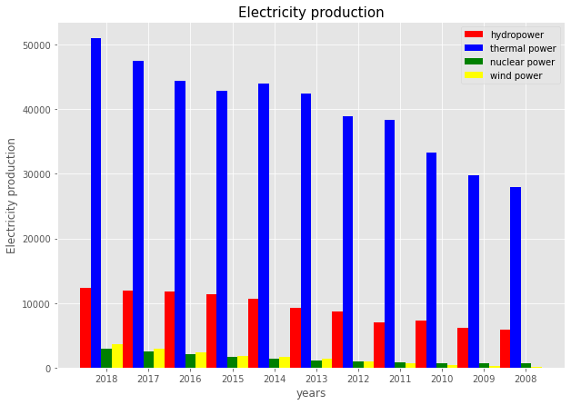

```python
x = [2018,2017,2016,2015,2014,2013,2012,2011,2010,2009,2008]
y1 = data_1['Electricity produced by hydropower']
y2 = data_1['Electricity produced by thermal power']
y3 = data_1['Electricity produced by nuclear power']
y4 = data_1['Electricity produced by wind power']

xticks = np.arange(len(x))

fig, ax = plt.subplots(figsize=(10, 7))
ax.bar(xticks, y1, width=0.25, label="hydropower", color="red")
ax.bar(xticks + 0.25, y2, width=0.25, label="thermal power", color="blue")
ax.bar(xticks + 0.5, y3, width=0.25, label="nuclear power", color="green")
ax.bar(xticks + 0.75, y4, width=0.25, label="wind power", color="yellow")

ax.set_title("Electricity production", fontsize=15)
ax.set_xlabel("years")
ax.set_ylabel("Electricity production")
ax.legend()

ax.set_xticks(xticks + 0.5)
ax.set_xticklabels(x)
```

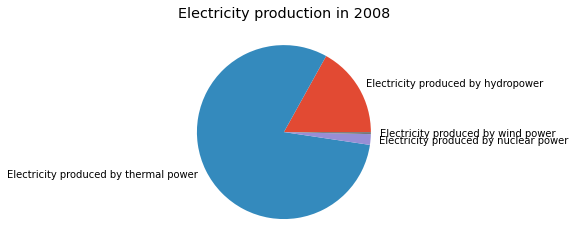

```python
x=["Electricity produced by hydropower",
"Electricity produced by thermal power",
"Electricity produced by nuclear power",
"Electricity produced by wind power" ]
y=[5851.9,27900.8,683.9,130.8]
explode=(0,0,0,0)
plt.pie(y,explode=explode, labels=x)
plt.title("Electricity production in 2008")
plt.show()
```

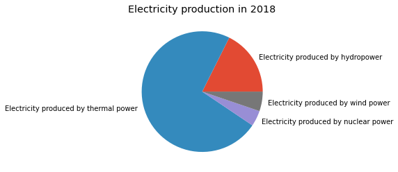

```python
x=["Electricity produced by hydropower",
"Electricity produced by thermal power",
"Electricity produced by nuclear power",
"Electricity produced by wind power" ]
y=[12317.9,50963.2,2943.6,3659.7]
explode=(0,0,0,0)
plt.pie(y,explode=explode, labels=x)
plt.title("Electricity production in 2018")
plt.show()
```

```python
import seaborn as sns
import os
```

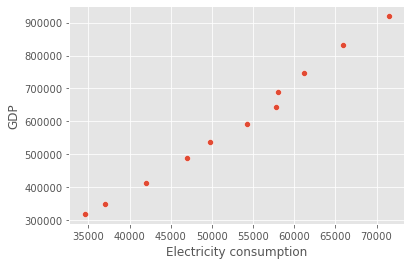

```python
sns.scatterplot(x='Electricity consumption',y='GDP',data=data_1)
```

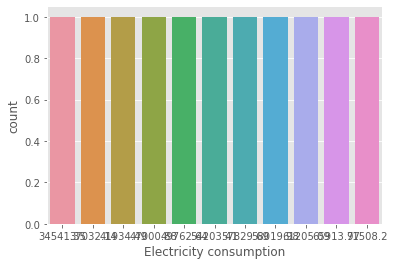

```python
sns.countplot(data=data_1,x='Electricity consumption')
```

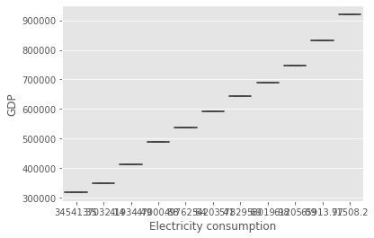

```python
sns.boxplot(x='Electricity consumption',y='GDP',data=data_1)
```

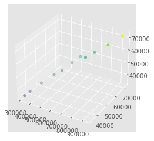

```python
from mpl_toolkits.mplot3d import Axes3D
fig = plt.figure()
ax = fig.add_subplot(111,projection='3d')
ax.scatter(data_1['GDP'],data_1['Electricity consumption'],data_1['Electricity production'],
           c=data_1['GDP'])
```

### 6.향후 진행 계획

- 모델 중에서 trend가 있기 때문에 구체적인 분석할 때 성(지역)별의 영향을 가지고 모델을 다시 만들어야 한다.
- 2015년 중국 전력 개혁을 진행하기 때문에 개혁 전 후에 데이터를 가지고 정책 효과 분석에 관한 논문을 쓸 만한지 생각해야 한다.
- 그래서 이상의 문제를 생각하고 데이터를 더 수집하고 다시 분석해야 한다.